# 1_cca

### load metadata

`r`r ##################################################  
####################meta_data##################### ##################################################

### RetrieveRNA-seqdata (TPM + count)

```r
##################################################
##################retrieve_rna_seq#################
##################################################
  ####tpm
  retrive_data_tpm <- function(project
                           ,cutoff = cut_point
                           ,l.base = 2)
  {
      fl.input.bp = paste0(fl.input,"/_basepair")
      fl.project = project

      lst = list.files(paste0(fl.input.bp,"/",fl.project)
                 ,pattern = ".txt")

      ###find genelist
      gene.list = as.character()

      for(i in 1:length(lst))
      {
        dum = read_delim(paste0(fl.input.bp,"/",fl.project,"/",lst[i])
                         ,delim = "\t")
        print(i)

        gene.list = c(gene.list,dum$Id)
      }
      gene.list = sort(unique(gene.list))

      dat = as.tibble(gene.list)
      names(dat) = "Symbol"

      ###add_val by TPM
      for(i in 1:length(lst))
      {
        dum = read_delim(paste0(fl.input.bp,"/",fl.project,"/",lst[i])
                         ,delim = "\t")
        dum2 = unlist(strsplit(lst[i],split = "[.]"))[1]

        dum3 = dum %>% dplyr::select(Symbol,TPM)

        names(dum3) = c("Symbol",paste0(dum2))
        dat = full_join(dat,dum3)

      }
      ###recheck cellline with master
      print(length(intersect(colnames(dat)[2:dim(dat)[2]],metadata_master$colname)) == length(lst))
      dat
  }

  dum = retrive_data_tpm("SO_6831")
  dum2 = retrive_data_tpm("SO_8069")

  dum = dum %>% filter(Symbol %in% intersect(dum$Symbol,dum2$Symbol))
  dum2 = dum2 %>% filter(Symbol %in% intersect(dum$Symbol,dum2$Symbol))
  ccadr_tpm_dat = full_join(dum,dum2)

  rm(dum,dum2)

  ####count
  retrive_data_count <- function(project
                                 ,l.base = 2)
  {
    fl.input.bp = paste0(fl.input,"/_basepair")
    fl.project = project

    lst = list.files(paste0(fl.input.bp,"/",fl.project)
                     ,pattern = ".txt")

    ###find genelist
    gene.list = as.character()

    for(i in 1:length(lst))
    {
      dum = read_delim(paste0(fl.input.bp,"/",fl.project,"/",lst[i])
                       ,delim = "\t")
      print(i)

      gene.list = c(gene.list,dum$Id)
    }
    gene.list = sort(unique(gene.list))

    dat = as.tibble(gene.list)
    names(dat) = "Symbol"

    ###add_val by Count
    for(i in 1:length(lst))
    {
      dum = read_delim(paste0(fl.input.bp,"/",fl.project,"/",lst[i])
                       ,delim = "\t"
                       )
      dum2 = unlist(strsplit(lst[i],split = "[.]"))[1]

      dum3 = dum %>% dplyr::select(Symbol,Count)
      names(dum3) = c("Symbol",paste0(dum2))
      dat = full_join(dat,dum3)

    }
    ###recheck cellline with master
    print(length(intersect(colnames(dat)[2:dim(dat)[2]],metadata_master$colname)) == length(lst))
    dat
  }

  dum = retrive_data_count("SO_6831")
  dum2 = retrive_data_count("SO_8069")

  dum = dum %>% filter(Symbol %in% intersect(dum$Symbol,dum2$Symbol))
  dum2 = dum2 %>% filter(Symbol %in% intersect(dum$Symbol,dum2$Symbol))
  ccadr_count_dat = full_join(dum,dum2)

  rm(dum,dum2)

  ccadr_count_dat = ccadr_count_dat %>%
                        gather(key = cellname, value = count,-Symbol) %>%
                        group_by(cellname) %>%
                        filter(cellname %in% (metadata_master %>%
                                               filter(ccadr_project) %>%
                                               pull(colname))) %>%
                        spread(key = cellname, value = count)

  ccadr_tpm_dat = ccadr_tpm_dat %>%
                      gather(key = cellname, value = count,-Symbol) %>%
                      group_by(cellname) %>%
                      filter(cellname %in% (metadata_master %>%
                                              filter(ccadr_project) %>%
                                              pull(colname))) %>%
                      spread(key = cellname, value = count)


##################################################

  ccadr_count_dat
  ccadr_tpm_dat
```

### Filter very low gene expression

`r`r

cut_point_tpm = 0 cut_point_count = 0 ################################################## ####################filter out#################### ##################################################  
ccadr_count = ccadr_count_dat %>% gather(key = cellname, value = count,-Symbol) %>% group_by(Symbol) %>% mutate(median_count = median(count)) %>% filter(median_count > cut_point_count)

ccadr_count = ccadr_count %>% dplyr::select(-median_count) %>% spread(key = cellname,value = count)

ccadr_tpm = ccadr_tpm_dat %>% gather(key = cellname, value = tpm,-Symbol) %>% group_by(Symbol) %>% mutate(median_tpm = median(tpm)) %>% filter(median_tpm > cut_point_tpm)

ccadr_tpm = ccadr_tpm %>% dplyr::select(-median_tpm) %>% spread(key = cellname,value = tpm)

ccadr_tpm = ccadr_tpm %>% group_by() ccadr_count = ccadr_count %>% group_by() ##################################################

ccadr_count

```
# A tibble: 13,390 x 36
   Symbol SO_6831_D068 SO_6831_D131 SO_6831_D138 SO_6831_HUCCA1 SO_6831_HUCCT1 SO_6831_Huh28 SO_6831_K055 SO_6831_K100 SO_6831_K156 SO_6831_K213
   <chr>         <dbl>        <dbl>        <dbl>          <dbl>          <dbl>         <dbl>        <dbl>        <dbl>        <dbl>        <dbl>
 1 A1BG-~           25            5           23              3              4             8           38           57            0            9
 2 A1CF              1            4           10              1              0             0            1            0            1            1
 3 A2M               7            2           21              1              1             1            6           15            0            1
 4 A4GALT            0            1            8              0              2             2            0            6            1            1
 5 AAAS              1            5            2              1              2             1            1            0            3            0
 6 AACS              2            5            5              0             10             0            7            1            5            1
 7 AADAC             0            4            1              3              0             0            0            6           10            1
 8 AADAC~           13            5            9             27              0             0            0            8           21            6
 9 AADAT             2            1            3              1              0             0            2            2            0            2
10 AAED1             2            0            1              4              3             2            4            6            4            2
# ... with 13,380 more rows, and 25 more variables: SO_6831_K214 <dbl>, SO_6831_MCF7 <dbl>, SO_6831_MMNK1 <dbl>, SO_6831_RBE <dbl>,
#   SO_6831_SSP25 <dbl>, SO_6831_T47D <dbl>, SO_6831_TFK1 <dbl>, SO_6831_YSCCC <dbl>, SO_6831_ZR751 <dbl>, SO_8069_D068 <dbl>, SO_8069_D131 <dbl>,
#   SO_8069_D138 <dbl>, SO_8069_HUCCA <dbl>, SO_8069_HUCCT <dbl>, SO_8069_HUH28 <dbl>, SO_8069_K055 <dbl>, SO_8069_K100 <dbl>, SO_8069_K156 <dbl>,
#   SO_8069_K213 <dbl>, SO_8069_K214 <dbl>, SO_8069_MMNK1 <dbl>, SO_8069_RBE <dbl>, SO_8069_SSP25 <dbl>, SO_8069_TFK1 <dbl>, SO_8069_YSCCC <dbl>
```

`r`r ccadr_tpm

```
# A tibble: 13,390 x 36
   Symbol SO_6831_D068 SO_6831_D131 SO_6831_D138 SO_6831_HUCCA1 SO_6831_HUCCT1 SO_6831_Huh28 SO_6831_K055 SO_6831_K100 SO_6831_K156 SO_6831_K213
   <chr>         <dbl>        <dbl>        <dbl>          <dbl>          <dbl>         <dbl>        <dbl>        <dbl>        <dbl>        <dbl>
 1 A1BG-~       54.4          10.2         38.2           6.54           6.67         14.8         78.9         110.          0           21.9
 2 A1CF          0.486         1.82         3.72          0.488          0             0            0.464         0           0.468        0.545
 3 A2M           6.97          1.86        16.0           0.999          0.764         0.848        5.70         13.3         0            1.12
 4 A4GALT        0             2.07        13.5           0              3.40          3.77         0            11.8         2.13         2.48
 5 AAAS          2.52         11.8          3.86          2.53           3.87          2.15         2.41          0           7.28         0
 6 AACS          2.79          6.52         5.33          0             10.7           0            9.32          1.24        6.71         1.56
 7 AADAC         0            10.8          2.20          8.68           0             0            0            15.4        27.8          3.23
 8 AADAC~       78.0          28.0         41.3         163.             0             0            0            42.6       121.          40.3
 9 AADAT         3.59          1.68         4.12          1.80           0             0            3.43          3.19        0            4.02
10 AAED1         7.56          0            2.89         15.2            8.70          6.44        14.4          20.2        14.6          8.47
# ... with 13,380 more rows, and 25 more variables: SO_6831_K214 <dbl>, SO_6831_MCF7 <dbl>, SO_6831_MMNK1 <dbl>, SO_6831_RBE <dbl>,
#   SO_6831_SSP25 <dbl>, SO_6831_T47D <dbl>, SO_6831_TFK1 <dbl>, SO_6831_YSCCC <dbl>, SO_6831_ZR751 <dbl>, SO_8069_D068 <dbl>, SO_8069_D131 <dbl>,
#   SO_8069_D138 <dbl>, SO_8069_HUCCA <dbl>, SO_8069_HUCCT <dbl>, SO_8069_HUH28 <dbl>, SO_8069_K055 <dbl>, SO_8069_K100 <dbl>, SO_8069_K156 <dbl>,
#   SO_8069_K213 <dbl>, SO_8069_K214 <dbl>, SO_8069_MMNK1 <dbl>, SO_8069_RBE <dbl>, SO_8069_SSP25 <dbl>, SO_8069_TFK1 <dbl>, SO_8069_YSCCC <dbl>
```

### Apply sva/Combat

```
dat = as.data.frame(dt %>% dplyr::select(-1))
rownames(dat) = as.character(dt$Symbol)

cl = colnames(dat)
cl_meta = full_join(metadata_master %>% dplyr::select(colname, project,cellline,treatment)
                    ,metadata_cellline %>% dplyr::select(cellline
                                                  ,organ
                                                  ,cca_source
                                                  ,celltype))


cl_meta = cl_meta %>% filter(colname %in% cl) %>% distinct()  %>% dplyr::select(-cellline)
cl_meta = as.data.frame(cl_meta)
rownames(cl_meta) = cl_meta$colname

cl_meta$project = as.factor(cl_meta$project)
cl_meta$celltype = as.factor(cl_meta$celltype)
cl_meta$organ = as.factor(cl_meta$organ)
cl_meta$cca_source = as.factor(cl_meta$cca_source)
cl_meta$treatment = as.factor(cl_meta$treatment)
cl_meta = cl_meta[,-1]
cl_meta$id = 1:dim(cl_meta)[1]
cl_meta$batch = as.numeric(cl_meta$project)

cl_meta$final = as.factor(paste(as.character(cl_meta$celltype)
                                ,
                                as.character(cl_meta$treatment)
                                ,sep = '_'))
cl_meta = cl_meta[,c(\id\,\batch\,\celltype\,\treatment\,\final\)]
colnames(cl_meta) = c(\sample\,\batch\,\celltype\,\treatment\,\final\)

modcombat = model.matrix(~final, data=cl_meta)

edata = as.matrix(dat)

cl_meta = cl_meta[colnames(dat),]

set.seed(1234)
combat_edata = ComBat(dat=edata
                      , batch=cl_meta$batch
                      , mod=modcombat
                      , par.prior=TRUE  , prior.plots=FALSE )
```

```
Standardizing Data across genes
```

`r`r ##################################################

fl_combat_ccadr_tpm <- (combat_ccadr_tpm)

### Generate Figure

```
###calculate %pcv of each gene in rep
metadata_rep1 = metadata_master %>%
  dplyr::select(colname,  cellline, full_name, rep, project) %>%
  filter(colname %in% colnames(dt)[-1]) %>%
  arrange(colname) %>% filter(project %in% \SO_6831\)

metadata_rep2 = metadata_master %>%
  dplyr::select(colname,  cellline, full_name, rep, project) %>%
  filter(colname %in% colnames(dt)[-1]) %>%
  arrange(colname) %>% filter(project %in% \SO_8069\)

#combind data
z_mat <- function(dt = dt, prt
                  ,n
                  ,l.base = 2
)
{
  rep_dat = dt %>% dplyr::select(Symbol
                          ,as.data.frame(metadata_master %>%
                                           filter(project == prt,ccadr_project) %>%
                                           dplyr::select(colname)
                          )[,1]
  )
  dat1 = as.data.frame(rep_dat)
  print(dim(rep_dat))
  r.name = dat1[,1]
  dat1 = dat1[,-1]
  rownames(dat1) = r.name

  dat1 = log(dat1 +1,base = l.base)
  u = t(scale(t(dat1)))
  u = u[,n]
  print(dim(u))
  u
}

combind_mat <- function(dt = dt,prt
                        ,n)
{
  rep_dat = dt %>% dplyr::select(Symbol
                          ,as.data.frame(metadata_master %>%
                                           filter(project == prt,ccadr_project) %>%
                                           dplyr::select(colname)
                          )[,1]
  )
  dat1 = as.data.frame(rep_dat)
  print(dim(rep_dat))
  r.name = dat1[,1]
  dat1 = dat1[,-1]
  rownames(dat1) = r.name

  dat1[,n]
}


c_dat1 = combind_mat(dt = dt, prt = \SO_6831\
                     ,n = metadata_rep1$colname)
```

```
[1] 13390    20
```

`r`r

```
c_dat2 = combind_mat(dt = dt,prt = \SO_8069\
                     ,n = metadata_rep2$colname)
```

```
[1] 13390    17
```

`r`r

```
dat = cbind(c_dat1,c_dat2)
#pca



res.pca = prcomp(t(dat)
                 ,center = TRUE
                 ,scale = TRUE)

plot(cumsum((res.pca$sdev)^2/sum((res.pca$sdev)^2))
     ,xlab = \PC\
     ,ylab = \Cummulation % var explain\
     ,main = paste0(\Cummulation % var explain | \,dtname))
```

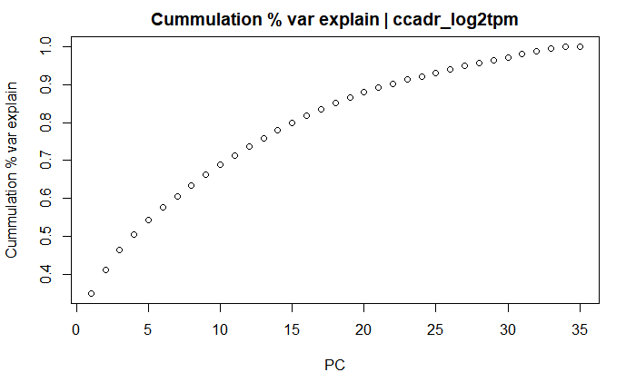

`r`r factoextra::fviz_eig(res.pca)

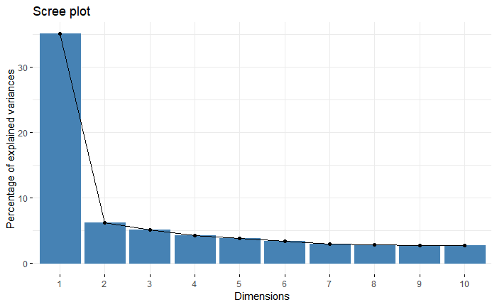

`r`r

```
res.pca.cell = as.data.frame(res.pca$x[,1:2])
res.pca.cell = cbind(rownames(res.pca.cell),res.pca.cell)
colnames(res.pca.cell) = c(\colname\,\PC1\,\PC2\)
res.pca.cell = as_tibble(res.pca.cell) %>% mutate(colname = as.character(colname))

res.pca.cell = left_join(res.pca.cell,metadata_master) %>% mutate(project = ifelse(project == \SO_6831\,\batch1\,\batch2\))
p.pca.prior =  ggplot(res.pca.cell,aes(x = PC1, y = PC2, color = project, label = full_name)) +
  geom_point() +
  ggtitle(paste0(\PCA of 2 batch | before Combat | \,dtname)) +
  ggrepel::geom_text_repel(aes(label = full_name)
                           ,box.padding   = 0.1
                           ,point.padding = 0.2
                           ,seed = set.seed(1234)
                           ,segment.size = 1
                           ,size = 5
  ) + geom_path(aes(group = abbv_name)) +
  xlab(paste0(\PC1 (\,round(((res.pca$sdev)^2/sum((res.pca$sdev)^2))[1]*100,2),\ %)\)) +
  ylab(paste0(\PC1 (\,round(((res.pca$sdev)^2/sum((res.pca$sdev)^2))[2]*100,2),\ %)\))


 #tsne
set.seed(42)
dat_tsne = Rtsne::Rtsne(t(dat)
                        , dims = 2
                        , perplexity=10
                        , verbose=FALSE
                        , max_iter = 5000
                        , pca_center = TRUE
                        , pca_scale = TRUE

                        ##,theta = 0
)
xy_tsne = dat_tsne$Y
rownames(xy_tsne) = colnames(dat)
xy_tsne = as.data.frame(xy_tsne)

res.pca.cell = cbind(rownames(xy_tsne),xy_tsne)
colnames(res.pca.cell) = c(\colname\,\tsne1\,\tsne2\)
res.pca.cell = as_tibble(res.pca.cell) %>% mutate(colname = as.character(colname))

res.pca.cell = left_join(res.pca.cell,metadata_master)  %>% mutate(project = ifelse(project == \SO_6831\,\batch1\,\batch2\))


p.tsne.prior =  ggplot(res.pca.cell,aes(x = tsne1, y = tsne2
                             , color = project
                             , label = full_name)) +
  geom_point() +
  ggtitle(paste0(\tsne of 2 batch | before Combat | \,dtname)) +
  ggrepel::geom_text_repel(aes(label = full_name)
                           ,box.padding   = 0.1
                           ,point.padding = 0.2
                           ,seed = set.seed(1234)
                           ,segment.size = 1
                           ,size = 5
  ) +
  geom_path(aes(group = abbv_name))
```

#####################

```
cl = colnames(dat)
cl_meta = full_join(metadata_master %>% dplyr::select(colname, project,cellline,treatment)
                    ,metadata_cellline %>% dplyr::select(cellline
                                                  ,organ
                                                  ,cca_source

                                                  ,celltype))


cl_meta = cl_meta %>% filter(colname %in% cl) %>% distinct()  %>% dplyr::select(-cellline)
cl_meta = as.data.frame(cl_meta)
rownames(cl_meta) = cl_meta$colname

cl_meta$project = as.factor(cl_meta$project)
cl_meta$celltype = as.factor(cl_meta$celltype)
cl_meta$organ = as.factor(cl_meta$organ)
cl_meta$cca_source = as.factor(cl_meta$cca_source)
cl_meta$treatment = as.factor(cl_meta$treatment)
cl_meta = cl_meta[,-1]
cl_meta$id = 1:dim(cl_meta)[1]
cl_meta$batch = as.numeric(cl_meta$project)

cl_meta$final = as.factor(paste(as.character(cl_meta$celltype)
                                ,
                                as.character(cl_meta$treatment)
                                ,sep = '_'))
cl_meta = cl_meta[,c(\id\,\batch\,\celltype\,\treatment\,\final\)]
colnames(cl_meta) = c(\sample\,\batch\,\celltype\,\treatment\,\final\)

modcombat = model.matrix(~final, data=cl_meta)

edata = as.matrix(dat)

cl_meta = cl_meta[colnames(dat),]

set.seed(1234)
combat_edata = ComBat(dat=edata
                      , batch=cl_meta$batch
                      , mod=modcombat
                      , par.prior=TRUE  , prior.plots=FALSE )
```

```
Standardizing Data across genes
```

`r`r #pca dat = combat_edata res.pca = prcomp(t(dat) ,center = TRUE ,scale = TRUE)

```
plot(cumsum((res.pca$sdev)^2/sum((res.pca$sdev)^2))
     ,xlab = \PC\
     ,ylab = \Cummulation % var explain\
     ,main = paste0(\Cummulation % var explain | \,dtname))
```

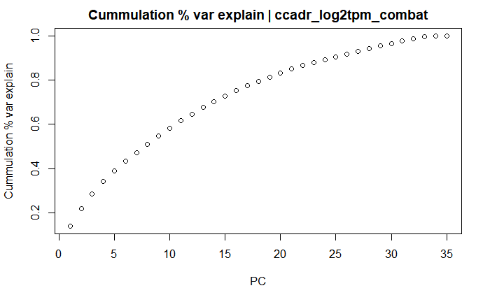

```
res.pca.cell = as.data.frame(res.pca$x[,1:2])
res.pca.cell = cbind(rownames(res.pca.cell),res.pca.cell)
colnames(res.pca.cell) = c(\colname\,\PC1\,\PC2\)
res.pca.cell = as_tibble(res.pca.cell) %>% mutate(colname = as.character(colname))

res.pca.cell = left_join(res.pca.cell,metadata_master) %>% mutate(project = ifelse(project == \SO_6831\,\batch1\,\batch2\))



p.pca.after = ggplot(res.pca.cell,aes(x = PC1, y = PC2, color = project, label = full_name)) +
  geom_point() +
  ggtitle(paste0(\PCA of 2 batch | after Combat | \,dtname)) +
  ggrepel::geom_text_repel(aes(label = full_name)
                           ,box.padding   = 0.1
                           ,point.padding = 0.2
                           ,seed = set.seed(1234)
                           ,segment.size = 1
                           ,size = 5
  ) + geom_path(aes(group = abbv_name)) +
  xlab(paste0(\PC1 (\,round(((res.pca$sdev)^2/sum((res.pca$sdev)^2))[1]*100,2),\ %)\)) +
  ylab(paste0(\PC1 (\,round(((res.pca$sdev)^2/sum((res.pca$sdev)^2))[2]*100,2),\ %)\))
#tsne
set.seed(42)
dat_tsne = Rtsne::Rtsne(t(dat)
                        , dims = 2
                        , perplexity=10
                        , verbose=FALSE
                        , max_iter = 5000
                        , pca_center = TRUE
                        , pca_scale = TRUE

                        ##,theta = 0
)
xy_tsne = dat_tsne$Y
rownames(xy_tsne) = colnames(dat)
xy_tsne = as.data.frame(xy_tsne)

res.pca.cell = cbind(rownames(xy_tsne),xy_tsne)
colnames(res.pca.cell) = c(\colname\,\tsne1\,\tsne2\)
res.pca.cell = as_tibble(res.pca.cell) %>% mutate(colname = as.character(colname))

res.pca.cell = left_join(res.pca.cell,metadata_master) %>% mutate(project = ifelse(project == \SO_6831\,\batch1\,\batch2\))

p.tsne.after = ggplot(res.pca.cell,aes(x = tsne1, y = tsne2
                            , color = project
                            , label = abbv_name)) +
  geom_point() +
  ggtitle(paste0(\tsne of 2 batch | after Combat | \,dtname)) +
  ggrepel::geom_text_repel(aes(label = full_name)
                           ,box.padding   = 0.1
                           ,point.padding = 0.2
                           ,seed = set.seed(1234)
                           ,segment.size = 1
                           ,size = 5
  ) +
  geom_path(aes(group = abbv_name))
```

#####################

##################### ########figure####### #####################

[figure not shown]

`r`r #####################

write_csv(repl_fl_combat_ccadr_tpm ,paste0(fl.output,‘/repl_fl_combat_ccadr_log2tpm_PB_’,‘.csv’))

### Median of expression

median_log2tpm_combat = left_join(dat %>% gather(key = colname, value = exp_tpm, -Symbol) ,mt.dat %>% select(colname, q)) %>% group_by(q, Symbol) %>% mutate(med.exp = median(exp_tpm)) %>% select(Symbol,q,med.exp) %>% group_by() %>% distinct() %>% spread(key = q, value = med.exp)

`r`r #write median_log2tpm_combat write_csv(median_log2tpm_combat ,paste0(fl.output,‘/median_log2tpm_combat_PB_’,‘.csv’))